# ▒선형회귀분석▒

## 0. 환경설정

```python
import pandas as pd
import numpy as np
import os
import matplotlib.pyplot as plt
import seaborn as sns
from functools import reduce
from pandas.plotting import scatter_matrix
import statsmodels.api as sm
import statsmodels.stats.api as sms
from statsmodels.formula.api import ols
from statsmodels.stats.stattools import durbin_watson
from statsmodels.compat import lzip
from statsmodels.stats.diagnostic import het_breuschpagan
import scipy


pd.set_option('display.float_format', '{:.2f}'.format)
np.set_printoptions(formatter={'float_kind': lambda x: "{0:.2f}".format(x)})
```

```python
import warnings
warnings.filterwarnings(action = 'ignore')
```

**(Question) 전유면적, 일반거래시세는 회수가능금액에 어떤 영향을 미칠까?**

## 1. 데이터 불러오기

**[데이터 다운로드]**

- C드라이브에 [Python_project] 생성
- [Python_project] 하위폴더로 [DAT] 폴더 생성
- 데이터 스토어에서 샘플데이터(3.아파트_주소기반_주택지역특성시세정보_DB.xlsx)를 "/python_project/DAT/"에 다운로드  
  (https://www.datastore.or.kr/file/detail?id=2c0a9616-4d78-403c-9d77-3db2effb2a74&page=1&viewCount=10&sort=1&order=1&source=1&keyword=%EC%95%84%ED%8C%8C%ED%8A%B8)
- 서울/수도권 및 5대광역시 아파트에 대한 주소테이블 외 4개의 테이블(정보집단)로 구성되며 각각 주택특성정보, 지역특성정보, 가격/신뢰등급/예상회수율정보 테이블로 이루어져 있고, 각 테이블간은 고유키값(NUM)으로 연계되어 있음

**[데이터 호출]**

```python
dirFolder = 'C:/Users/Admin/Begas_Edu_Finacial_Preprocess/python_project/dat'
fileName = '3.아파트_주소기반_주택지역특성시세정보_DB.xlsx'

DF1 =pd.read_excel(os.path.join(dirFolder, fileName), sheet_name = 0)
DF2 =pd.read_excel(os.path.join(dirFolder, fileName), sheet_name = 1)
DF3 =pd.read_excel(os.path.join(dirFolder, fileName), sheet_name = 2)
DF4 =pd.read_excel(os.path.join(dirFolder, fileName), sheet_name = 3)

DF = reduce(lambda x,y: pd.merge(x,y) , [DF1, DF2, DF3, DF4])
DF['LAND_ACCESS'] = DF['LAND_ACCESS'].astype('float64')

regDF = DF[['PRIV_AREA', 'PRICE_GEN', 'AVM_RECOVER']]

regDF.head()
```

|  | PRIV_AREA | PRICE_GEN | AVM_RECOVER |
| --- | --- | --- | --- |
| 0 | 126.34 | 124000 | 114000 |
| 1 | 147.31 | 131000 | 121000 |
| 2 | 94.51 | 107000 | 99000 |
| 3 | 105.07 | 70600 | 65500 |
| 4 | 140.78 | 131000 | 121000 |

- PRIV_AREA : 전유면적
- PRICE_GEN : 일반거래시세
- AVM_RECOVER : 회수가능금액

**[ 데이터 검토 ]** 산점도

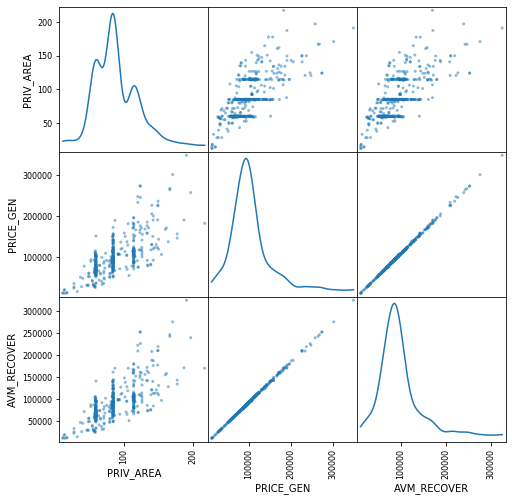

```python
scatter_matrix(regDF,
               alpha=0.5,
               figsize=(8, 8),
               diagonal='kde')

plt.show()
```

**[ 데이터 검토 ]** Boxplot

```python
regDF
```

|  | PRIV_AREA | PRICE_GEN | AVM_RECOVER |
| --- | --- | --- | --- |
| 0 | 126.34 | 124000 | 114000 |
| 1 | 147.31 | 131000 | 121000 |
| 2 | 94.51 | 107000 | 99000 |
| 3 | 105.07 | 70600 | 65500 |
| 4 | 140.78 | 131000 | 121000 |
| ... | ... | ... | ... |
| 495 | 84.91 | 101000 | 94000 |
| 496 | 84.91 | 93000 | 86100 |
| 497 | 84.75 | 91600 | 84500 |
| 498 | 84.91 | 98300 | 91100 |
| 499 | 84.99 | 111000 | 102000 |

500 rows × 3 columns

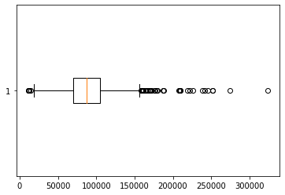

```python
plt.boxplot(regDF['AVM_RECOVER'],
           vert = 0)
plt.show()
```

## 2. 선형회귀분석

### 2.1 모형적합

```python
regModel = ols('AVM_RECOVER ~ PRIV_AREA + PRICE_GEN', data = regDF).fit()
```

y=190.3087+2.4194x1+0.9163x2  
→ 전유면적(PRIV_AREA)를 1단위 증가하면 회수가능 금액이 2.4194만큼 증가  
→ 일반거래시세(PRICE_GEN)를 1단위 증가하면 회수가능 금액이 0.9163만큼 증가

**[ 결과 ]** 모형 결과 Summary

```python
print(regModel.summary())
```

```
                            OLS Regression Results
==============================================================================
Dep. Variable:            AVM_RECOVER   R-squared:                       0.999
Model:                            OLS   Adj. R-squared:                  0.999
Method:                 Least Squares   F-statistic:                 4.161e+05
Date:                Tue, 04 Aug 2020   Prob (F-statistic):               0.00
Time:                        11:02:59   Log-Likelihood:                -4157.4
No. Observations:                 500   AIC:                             8321.
Df Residuals:                     497   BIC:                             8333.
Df Model:                           2
Covariance Type:            nonrobust
==============================================================================
                 coef    std err          t      P>|t|      [0.025      0.975]
------------------------------------------------------------------------------
Intercept    190.3087    138.517      1.374      0.170     -81.843     462.461
PRIV_AREA      2.4194      2.111      1.146      0.252      -1.727       6.566
PRICE_GEN      0.9163      0.001    638.242      0.000       0.913       0.919
==============================================================================
Omnibus:                      212.591   Durbin-Watson:                   1.192
Prob(Omnibus):                  0.000   Jarque-Bera (JB):             1514.531
Skew:                          -1.693   Prob(JB):                         0.00
Kurtosis:                      10.825   Cond. No.                     3.45e+05
==============================================================================

Warnings:
[1] Standard Errors assume that the covariance matrix of the errors is correctly specified.
[2] The condition number is large, 3.45e+05. This might indicate that there are
strong multicollinearity or other numerical problems.
```

**[ 예측 ]**

```python
fitted = regModel.predict(regDF)
fitted
```

```
0     114116.97
1     120581.79
2      98462.89
3      65135.18
4     120565.99
         ...
495    92941.87
496    85611.48
497    84328.28
498    90467.87
499   102105.05
Length: 500, dtype: float64
```

**[ 잔차 ]**  
실제값과 예측값을 이용해 구할 수 있으며, **resid 메소드**를 이용해서 구할 수 있다. 두 값이 같은 것을 아래와 같이 확인할 수 있다.

```python
residual = regDF['AVM_RECOVER'] - fitted
residual
```

```
0     -116.97
1      418.21
2      537.11
3      364.82
4      434.01
        ...
495   1058.13
496    488.52
497    171.72
498    632.13
499   -105.05
Length: 500, dtype: float64
```

```python
regModel.resid
```

```
0     -116.97
1      418.21
2      537.11
3      364.82
4      434.01
        ...
495   1058.13
496    488.52
497    171.72
498    632.13
499   -105.05
Length: 500, dtype: float64
```

### 2.2 잔차분석

**[독립성]** Durbin-Watson 통계량

```python
#perform Durbin-Watson test
durbin_watson(regModel.resid)
```

```
1.1923213904483765
```

**[정규성]** Q-Q plot

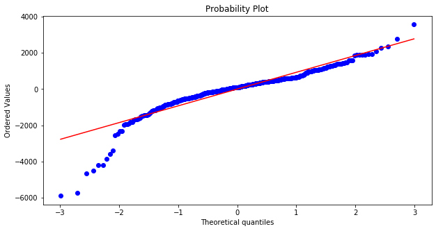

```python
plt.figure(figsize = (10, 5))
scipy.stats.probplot(regModel.resid, plot = plt)
plt.show()
```

**[정규성]** jarque bera

```python
name = ['Jarque-Bera', 'Chi^2 two-tail prob.', 'Skew', 'Kurtosis']
test = sms.jarque_bera(regModel.resid)
lzip(name, test)
```

```
[('Jarque-Bera', 1514.5307964196252),
 ('Chi^2 two-tail prob.', 0.0),
 ('Skew', -1.6927544509793573),
 ('Kurtosis', 10.825331156117313)]
```

**[등분산성]** 잔차 산점도

- 예측값과 잔차(residual)을 비교함
- 모든 예측값에서 잔차가 유사하게 있어야 함
- 빨간 실선은 잔차의 추세를 나타냄

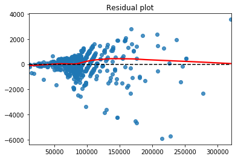

```python
sns.regplot(fitted, regModel.resid, lowess = True, line_kws = {'color':'red'})
plt.plot([fitted.min(), fitted.max()], [0, 0], '--', color='black')
plt.title('Residual plot')
plt.show()
```

**[등분산성]** Breusch-Pagan Test

```python
name = ['Lagrange multiplier statistic', 'p-value',
        'f-value', 'f p-value']
bp_Test = het_breuschpagan(regModel.resid, regModel.model.exog)
bp_Test
lzip(name, bp_Test)
```

```
[('Lagrange multiplier statistic', 93.80961584308234),
 ('p-value', 4.260894144507931e-21),
 ('f-value', 57.39104234432171),
 ('f p-value', 3.760702454299088e-23)]
```

### 2.3 변수선택

```python
y = regDF['AVM_RECOVER']
X = regDF[['PRIV_AREA', 'PRICE_GEN']]
```

**[후진 소거법]**

```python
def backward_elimination(data, target,significance_level = 0.05):
    features = data.columns.tolist()
    while(len(features)>0):
        features_with_constant = sm.add_constant(data[features])
        p_values = sm.OLS(target, features_with_constant).fit().pvalues[1:]
        max_p_value = p_values.max()
        if(max_p_value >= significance_level):
            excluded_feature = p_values.idxmax()
            features.remove(excluded_feature)
        else:
            break
    return features
```

```python
backward_elimination(X, y)
```

```
['PRICE_GEN']
```

**[단계적 선택법]**

```python
def stepwise_selection(data, target,SL_in=0.05,SL_out = 0.05):
    initial_features = data.columns.tolist()
    best_features = []
    while (len(initial_features)>0):
        remaining_features = list(set(initial_features)-set(best_features))
        new_pval = pd.Series(index=remaining_features)
        for new_column in remaining_features:
            model = sm.OLS(target, sm.add_constant(data[best_features+[new_column]])).fit()
            new_pval[new_column] = model.pvalues[new_column]
        min_p_value = new_pval.min()
        if(min_p_value<SL_in):
            best_features.append(new_pval.idxmin())
            while(len(best_features)>0):
                best_features_with_constant = sm.add_constant(data[best_features])
                p_values = sm.OLS(target, best_features_with_constant).fit().pvalues[1:]
                max_p_value = p_values.max()
                if(max_p_value >= SL_out):
                    excluded_feature = p_values.idxmax()
                    best_features.remove(excluded_feature)
                else:
                    break
        else:
            break
    return best_features
```

```python
stepwise_selection(X, y)
```

```
['PRICE_GEN']
```

**[전진선택법]**

```python
def forward_selection(data, target, significance_level=0.05):
    initial_features = data.columns.tolist()
    best_features = []
    while (len(initial_features)>0):
        remaining_features = list(set(initial_features)-set(best_features))
        new_pval = pd.Series(index=remaining_features)
        for new_column in remaining_features:
            model = sm.OLS(target, sm.add_constant(data[best_features+[new_column]])).fit()
            new_pval[new_column] = model.pvalues[new_column]
        min_p_value = new_pval.min()
        if(min_p_value<significance_level):
            best_features.append(new_pval.idxmin())
        else:
            break
    return best_features
```

```python
forward_selection(X, y)
```

```
['PRICE_GEN']
```

**[모형선택]**

```python
# AIC
print(regModel.aic)
```

```
8320.846028711294
```

```python
# BIC
print(regModel.bic)
```

```
8333.48985300656
```